# HW_07_Soln-V4

**Machine Learning for Mechanical Engineering**  
**Homework 7**  
**Due Wednesday, 05/16/2018, 9:30 AM**

|  | by Prof. Seungchul Lee Industrial AI Lab POSTECH |
| --- | --- |

- For your handwritten solution, hand in your hardcopy at class.
- For your code, email your .ipynb file to (`iai.postech@gmail.com`)
- When you send an e-mail, write down [Machine Learning HW7] on the title
- And please write your NAME on your .ipynb files. ex) 김지원_20182315_HW7.ipynb
- Do not submit a printed version of your code. It will not be graded.

# Problem 1:

In this problem, we would like to explore on how to decide the number of latent space in an autoenocoder. Let's use MNIST data set and autoencoder structure that we used in class.

- change the number of latent variables from 1 to 20
- and compute the loss fuction for each case to see how well the autoencoder reconstructs the input
- You are expected to plot the graph similar to the below one.

Then state your justification for the number of latent variable on your own word. (note that there is no right answer for the specific number of latent variable in this problem)

Hint: the basic idea or approach is similar to that of K-means.

[figure not shown]

# Problem 2: Denoising Autoencoder

An autoencoder is a neural network used for dimensionality reduction; that is, for feature selection and extraction. In denoising autoencoders, a random noise is deliberately added to the input and network is forced to reconstruct the unadulterated input. The decoder function learns to resist small changes in the input. This pretraining result in a robust neural network which is immune to noise in input up to a certain extent. We want to build the model to reconstruct the original signals from the noisy one.

Download [denoising_AE](https://www.dropbox.com/sh/lbrd4cgcnh4b5u6/AADfs4dFkE6GX57aNdCWS9e9a?dl=1) data.

[figure not shown]

```python
import tensorflow as tf
import numpy as np
import matplotlib.pyplot as plt
from six.moves import cPickle
```

```python
from tensorflow.examples.tutorials.mnist import input_data

#load mnist data
mnist = input_data.read_data_sets("MNIST_data/",one_hot = True)
```

```
Successfully downloaded train-images-idx3-ubyte.gz 9912422 bytes.
Extracting MNIST_data/train-images-idx3-ubyte.gz
Successfully downloaded train-labels-idx1-ubyte.gz 28881 bytes.
Extracting MNIST_data/train-labels-idx1-ubyte.gz
Successfully downloaded t10k-images-idx3-ubyte.gz 1648877 bytes.
Extracting MNIST_data/t10k-images-idx3-ubyte.gz
Successfully downloaded t10k-labels-idx1-ubyte.gz 4542 bytes.
Extracting MNIST_data/t10k-labels-idx1-ubyte.gz
```

```python
#shape of input and latent variable

#shape of input
n_input = 28*28

#encoder shape
n_encoder = 128

n_latent = 32

#decoder shape
n_decoder = 128
```

```python
#define weights and biases

weights = {
    'encoder' : tf.Variable(tf.random_normal([n_input,n_encoder], stddev=0.1)),
    'latent' : tf.Variable(tf.random_normal([n_encoder,n_latent], stddev=0.1)),
    'decoder' : tf.Variable(tf.random_normal([n_latent,n_decoder], stddev = 0.1)),
    'reconst' : tf.Variable(tf.random_normal([n_decoder,n_input], stddev = 0.1))
}

biases = {
    'encoder' : tf.Variable(tf.random_normal([n_encoder], stddev=0.1)),
    'latent': tf.Variable(tf.random_normal([n_latent], stddev=0.1)),
    'decoder' : tf.Variable(tf.random_normal([n_decoder], stddev=0.1)),
    'reconst' : tf.Variable(tf.random_normal([n_input], stddev=0.1))
}

x = tf.placeholder(tf.float32, [None, n_input])
original = tf.placeholder(tf.float32, [None, n_input])
```

```python
#encoder function
def encoder(x, weights, biases):
    encoder = tf.add(tf.matmul(x, weights['encoder']), biases['encoder'])
    encoder = tf.nn.relu(encoder)

    latent = tf.add(tf.matmul(encoder, weights['latent']), biases['latent'])

    return latent
```

```python
#decoder function
def decoder(latent, weights, biases):
    decoder = tf.add(tf.matmul(latent, weights['decoder']), biases['decoder'])
    decoder = tf.nn.relu(decoder)

    reconst = tf.add(tf.matmul(decoder, weights['reconst']), biases['reconst'])
# to improve reconstruction image performance, use a nonlinear activation with sigmoid
    reconst = tf.nn.sigmoid(reconst)
    return reconst
```

When calculating the loss function, it is important to compare the output values with the original input, not with the corrupted input.

```python
LR = 0.0001

latent = encoder(x, weights, biases)
reconst = decoder(latent, weights, biases)
loss = tf.square(tf.subtract(original, reconst))
loss = tf.reduce_mean(loss)

optm = tf.train.AdamOptimizer(LR).minimize(loss)

init = tf.global_variables_initializer()
```

```python
n_batch = 50
n_iter = 5500
n_prt = 250
```

```python
sess = tf.Session()
sess.run(init)
```

```python
x_train_noisy = cPickle.load(open('./data_files/x_train_noisy.pkl','rb'))
x_train_original = cPickle.load(open('./data_files/original_train_mnist.pkl','rb'))
```

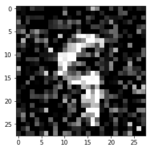

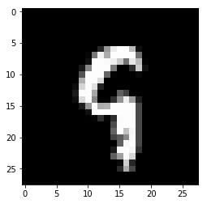

```python
idx = np.random.randint(mnist.train.images.shape[0], size = 1)
plt.imshow(x_train_noisy[idx].reshape(28,28),'gray')
plt.show()
plt.imshow(x_train_original[idx].reshape(28,28),'gray')
plt.show()
```

Train your autoencoder model.

```python
for epoch in range(n_iter):
    idx = np.random.randint(mnist.train.images.shape[0], size = n_batch)
    noisy_x = [x_train_noisy[i] for i in idx]
    origin_x = [x_train_original[i] for i in idx]
    sess.run(optm, feed_dict = {x : noisy_x, original : origin_x})

    if epoch % n_prt == 0:
        cost = sess.run(loss, feed_dict={x: noisy_x, original: origin_x})
        print("Iter : {}".format(epoch))
        print("Cost : {}".format(cost))
```

```
Iter : 0
Cost : 0.23920464515686035
Iter : 250
Cost : 0.06968358159065247
Iter : 500
Cost : 0.06577717512845993
Iter : 750
Cost : 0.056717634201049805
Iter : 1000
Cost : 0.048259537667036057
Iter : 1250
Cost : 0.04365135729312897
Iter : 1500
Cost : 0.03806641325354576
Iter : 1750
Cost : 0.03759477287530899
Iter : 2000
Cost : 0.03534483537077904
Iter : 2250
Cost : 0.035030119121074677
Iter : 2500
Cost : 0.03245969116687775
Iter : 2750
Cost : 0.032829400151968
Iter : 3000
Cost : 0.032662779092788696
Iter : 3250
Cost : 0.02794581837952137
Iter : 3500
Cost : 0.027690330520272255
Iter : 3750
Cost : 0.030037598684430122
Iter : 4000
Cost : 0.0286245197057724
Iter : 4250
Cost : 0.026725366711616516
Iter : 4500
Cost : 0.027825672179460526
Iter : 4750
Cost : 0.025558318942785263
Iter : 5000
Cost : 0.026219790801405907
Iter : 5250
Cost : 0.022144965827465057
```

Test/evaluate your autoencoder model.

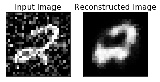

```python
idx = np.random.randint(x_train_noisy.shape[0])
noisy_x = x_train_noisy[idx].reshape((-1,784))
x_reconst = sess.run(reconst, feed_dict = {x : noisy_x})

fig = plt.figure(figsize=(5, 3))
ax1 = fig.add_subplot(1, 2, 1)
ax1.imshow(noisy_x.reshape(28, 28), 'gray')
ax1.set_title('Input Image', fontsize=15)
ax1.set_xticks([])
ax1.set_yticks([])

ax2 = fig.add_subplot(1, 2, 2)
ax2.imshow(x_reconst.reshape(28, 28), 'gray')
ax2.set_title('Reconstructed Image', fontsize=15)
ax2.set_xticks([])
ax2.set_yticks([])
plt.show()
```

# Problem 3: Sign language recognition

In this problem, you are asked to use CNN. By doing this to recognize the given sign language, we hope that you are getting familiar with the CNN algorithm. We have the images of sign language from 0 to 5.

Download [Sign_language](https://www.dropbox.com/sh/assuoogqewv02fl/AACAVsgpp6H1TCYDwfU2Fc3va?dl=1) data,

```python
import numpy as np
import matplotlib.pyplot as plt
import tensorflow as tf
from six.moves import cPickle
```

```python
#load data

from six.moves import cPickle
image_set_train = cPickle.load(open('./data_files/image_set_train.pkl', 'rb'))
label_train = cPickle.load(open('./data_files/label_train.pkl', 'rb'))
image_set_test = cPickle.load(open('./data_files/image_set_test.pkl', 'rb'))
label_test = cPickle.load(open('./data_files/label_test.pkl', 'rb'))
```

```python
np.array(image_set_test).shape
```

```
(337, 100, 100)
```

```python
np.array(label_test).shape
```

```
(337, 6)
```

- Our data has six labels (0 to 5)
- the number of training data is 900
- the mumber of test data is 337

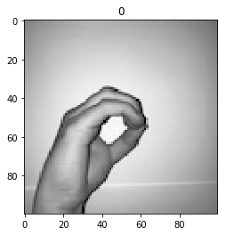

```python
idx = np.random.randint(len(image_set_train))
plt.imshow(image_set_train[idx],'gray')
plt.title(np.argmax(label_train[idx]))
plt.show()
```

Construct the CNN with two convolutional layers. Fill out the blank in the following cells.

```python
input_h  = 100 # Input height
input_w = 100 # Input width
input_ch = 1 # Input channel

## First convolution layer
# Filter size
k1_h = 4
k1_w = 4
# the number of channels
k1_ch = 8
# Pooling size
p1_h = 5
p1_w = 5

## Second convolution layer
# Filter size
k2_h = 2
k2_w = 2
# the number of channels
k2_ch = 16
# Pooling size
p2_h = 4
p2_w = 4

## Fully connected
# Flatten the features
conv_result_size = int((100/(5*4)) * (100/(5*4)) * k2_ch)
n_hidden1 = 100
n_output = 6
```

```python
weights = {
    'conv1' : tf.Variable(tf.random_normal([k1_h, k1_w, input_ch, k1_ch],stddev = 0.1)),
    'conv2' : tf.Variable(tf.random_normal([k2_h, k2_w, k1_ch, k2_ch],stddev = 0.1)),
    'hidden1' : tf.Variable(tf.random_normal([conv_result_size, n_hidden1], stddev = 0.1)),
    'output' : tf.Variable(tf.random_normal([n_hidden1, n_output], stddev = 0.1))
}

biases = {
    'conv1' : tf.Variable(tf.random_normal([k1_ch], stddev = 0.1)),
    'conv2' : tf.Variable(tf.random_normal([k2_ch], stddev = 0.1)),
    'hidden1' : tf.Variable(tf.random_normal([n_hidden1], stddev = 0.1)),
    'output' : tf.Variable(tf.random_normal([n_output], stddev = 0.1))
}

x = tf.placeholder(tf.float32, [None, input_h, input_w, input_ch])
y = tf.placeholder(tf.float32, [None, n_output])
```

```python
def net(x, weights, biases):
    ## First convolution layer
    conv1 = tf.nn.conv2d(x, weights['conv1'],
                         strides= [1, 1, 1, 1],
                         padding = 'SAME')
    conv1 = tf.nn.relu(tf.add(conv1, biases['conv1']))
    maxp1 = tf.nn.max_pool(conv1,
                           ksize = [1, p1_h, p1_w, 1],
                           strides = [1, p1_h, p1_w, 1],
                           padding = 'VALID'
                           )

    ## Second convolution layer
    conv2 = tf.nn.conv2d(maxp1, weights['conv2'],
                         strides= [1, 1, 1, 1],
                         padding = 'SAME')
    conv2 = tf.nn.relu(tf.add(conv2, biases['conv2']))
    maxp2 = tf.nn.max_pool(conv2,
                           ksize = [1, p2_h, p2_w, 1],
                           strides = [1, p2_h, p2_w, 1],
                           padding = 'VALID')

    # shape = conv2.get_shape().as_list()
    # maxp2_re = tf.reshape(conv2, [-1, shape[1]*shape[2]*shape[3]])
    maxp2_re = tf.reshape(maxp2, [-1, conv_result_size])

    ### Fully connected
    hidden1 = tf.add(tf.matmul(maxp2_re, weights['hidden1']), biases['hidden1'])
    hidden1 = tf.nn.relu(hidden1)
    output = tf.add(tf.matmul(hidden1, weights['output']), biases['output'])
    return output
```

```python
LR = 0.0001

pred = net(x, weights, biases)
loss = tf.nn.softmax_cross_entropy_with_logits(labels=y, logits=pred)
loss = tf.reduce_mean(loss)

# optimizer = tf.train.GradientDescentOptimizer(learning_rate).minimize(cost)
optm = tf.train.AdamOptimizer(LR).minimize(loss)

init = tf.global_variables_initializer()
```

[output not shown]

```python
n_batch = 50
n_iter = 2500
n_prt = 250
```

```python
sess = tf.Session()
sess.run(init)

# Training cycle
for epoch in range(n_iter):
    idx = np.random.randint(len(label_train), size=n_batch)
    train_x = [image_set_train[i] for i in idx]
    train_y = [label_train[i] for i in idx]
    train_x = np.reshape(np.array(train_x),(-1,100,100,1))
    sess.run(optm, feed_dict={x: train_x,  y: train_y})

    if epoch % n_prt == 0:
        c = sess.run(loss, feed_dict={x: train_x, y: train_y})
        print ("Iter : {}".format(epoch))
        print ("Cost : {}".format(c))
```

```
Iter : 0
Cost : 25.178691864013672
Iter : 250
Cost : 1.1721129417419434
Iter : 500
Cost : 0.36346739530563354
Iter : 750
Cost : 0.20691972970962524
Iter : 1000
Cost : 0.15486674010753632
Iter : 1250
Cost : 0.051839470863342285
Iter : 1500
Cost : 0.08433638513088226
Iter : 1750
Cost : 0.04034348949790001
Iter : 2000
Cost : 0.032203253358602524
Iter : 2250
Cost : 0.018229171633720398
```

Test/evaluate your CNN model.

```python
size = 100
idx = np.random.randint(len(label_test), size=size)
test_x = [image_set_test[i] for i in idx]
test_y = [label_test[i] for i in idx]

my_pred = sess.run(pred, feed_dict={x : np.array(test_x).reshape(-1,100,100,1)})
my_pred = np.argmax(my_pred, axis=1)

labels = np.argmax(test_y, axis=1)

accr = np.mean(np.equal(my_pred, labels))
print("Accuracy : {}%".format(accr*100))
```

```
Accuracy : 90.0%
```

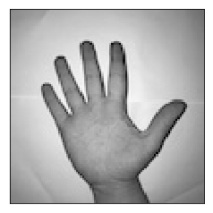

```
Label : 5
Prediction : 5
```

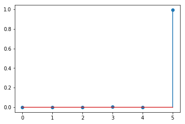

```
Probability : [0.   0.   0.   0.01 0.   0.99]
```

```python
size = 1
idx = np.random.randint(len(label_test), size=size)
test_x = [image_set_test[i] for i in idx]
test_y = [label_test[i] for i in idx]
logits = sess.run(tf.nn.softmax(pred), feed_dict={x : np.array(test_x).reshape(-1,100,100,1)})
predict = np.argmax(logits)

plt.imshow(test_x[0], 'gray')
plt.xticks([])
plt.yticks([])
plt.show()

print('Label : {}'.format(np.argmax(test_y[0])))
print('Prediction : {}'.format(predict))

plt.stem(logits.ravel())
plt.show()

np.set_printoptions(precision=2, suppress=True)
print('Probability : {}'.format(logits.ravel()))
```